# 2 R basics

[Book](http://rafalab.dfci.harvard.edu/dsbook/r-basics.html)

R commands in this chapter

`%in%` `args` `as.character` `as.data.frame` `as.numeric` `boxplot` `class` `data` `data.frame` `hist` `identical` `image` `is.na` `length` `levels` `ls` `match` `max` `mean` `names` `order` `plot` `reorder` `rank` `seq` `sort` `str` `sum` `table` `which` `which.max`

# 2.2 The very basics

Show all variables in the environment:

```r
ls()
```

```
## character(0)
```

Show arguments associated with a function: `args(function)`

```r
args(log)
```

```
## function (x, base = exp(1))
## NULL
```

Show all the available datasets by typing `data()`

```r
data()
```

This shows you the object name for these datasets. These datasets are objects that can be used by simply typing the name. For example, if you type:

```r
head(co2)
```

```
## [1] 315.42 316.31 316.50 317.56 318.13 318.00
```

R will show you Mauna Loa atmospheric CO2 concentration data.

**Motivating scripts**

```r
a <- 3
b <- 2
c <- -1
(-b + sqrt(b^2 - 4*a*c)) / (2*a)
```

```
## [1] 0.3333333
```

```r
(-b - sqrt(b^2 - 4*a*c)) / (2*a)
```

```
## [1] -1
```

# 2.4 Data types

Print class of object

```r
a <- 2
class(a)
```

```
## [1] "numeric"
```

## 2.4.1 Data frames

Load dataset `data()`

```r
# install.packages("dslabs")
library(dslabs)
data(murders)
```

```r
class(murders)
```

```
## [1] "data.frame"
```

## 2.4.2 Examining an object

```r
str(murders)
```

```
## 'data.frame':    51 obs. of  5 variables:
##  $ state     : chr  "Alabama" "Alaska" "Arizona" "Arkansas" ...
##  $ abb       : chr  "AL" "AK" "AZ" "AR" ...
##  $ region    : Factor w/ 4 levels "Northeast","South",..: 2 4 4 2 4 4 1 2 2 2 ...
##  $ population: num  4779736 710231 6392017 2915918 37253956 ...
##  $ total     : num  135 19 232 93 1257 ...
```

names()` Variable (column) names

```r
names(murders)
```

```
## [1] "state"      "abb"        "region"     "population" "total"
```

`head()`

```r
head(murders)
```

|  | state | abb | region | population | total |
| --- | --- | --- | --- | --- | --- |
| 1 | Alabama | AL | South | 4779736 | 135 |
| 2 | Alaska | AK | West | 710231 | 19 |
| 3 | Arizona | AZ | West | 6392017 | 232 |
| 4 | Arkansas | AR | South | 2915918 | 93 |
| 5 | California | CA | West | 37253956 | 1257 |
| 6 | Colorado | CO | West | 5029196 | 65 |

## 2.4.3 The accessor: `$`

```r
murders$population
```

```
##  [1]  4779736   710231  6392017  2915918 37253956  5029196  3574097   897934
##  [9]   601723 19687653  9920000  1360301  1567582 12830632  6483802  3046355
## [17]  2853118  4339367  4533372  1328361  5773552  6547629  9883640  5303925
## [25]  2967297  5988927   989415  1826341  2700551  1316470  8791894  2059179
## [33] 19378102  9535483   672591 11536504  3751351  3831074 12702379  1052567
## [41]  4625364   814180  6346105 25145561  2763885   625741  8001024  6724540
## [49]  1852994  5686986   563626
```

## 2.4.4 Vectors: numerics, characters, and logical

The object murders$population is not one number but several. We call these types of objects vectors. A single number is technically a vector of length 1, but in general we use the term vectors to refer to objects with several entries.

`length()` tells you how many entries are in the vector:

```r
pop <- murders$population
length(pop)
```

```
## [1] 51
```

```r
class(pop)
```

```
## [1] "numeric"
```

```r
class(murders$state)
```

```
## [1] "character"
```

```r
z <- 3 == 2
z
```

```
## [1] FALSE
```

```r
class(z)
```

```
## [1] "logical"
```

Mathematically, the values in pop are integers and there is an integer class in R. However, by default, numbers are assigned class numeric even when they are round integers. For example, class(1) returns numeric. You can turn them into class integer with the **`as.integer()`** function or by adding an L like this: 1L. Note the class by typing: class(1L)

2.4.5 Factors {#levels}

```r
class(murders$region)
```

```
## [1] "factor"
```

```r
levels(murders$region)
```

```
## [1] "Northeast"     "South"         "North Central" "West"
```

In the background, R stores these levels as integers and keeps a map to keep track of the labels. This is more memory efficient than storing all the characters.

For example, in the murders dataset regions are ordered from east to west. The function **`reorder`** lets us change the order of the levels of a factor variable based on a summary computed on a numeric vector. We will demonstrate this with a simple example, and will see more advanced ones in the Data Visualization part of the book.

Suppose we want the levels of the region by the total number of murders rather than alphabetical order. If there are values associated with each level, we can use the reorder and specify a data summary to determine the order. The following code takes the sum of the total murders in each region, and reorders the factor following these sums

```r
region <- murders$region
value <- murders$total
region <- reorder(region, value, FUN = sum)
levels(region)
```

```
## [1] "Northeast"     "North Central" "West"          "South"
```

The new order is in agreement with the fact that the Northeast has the least murders and the South has the most.

**Warning**: Factors can be a source of confusion since sometimes they behave like characters and sometimes they do not. As a result, confusing factors and characters are a common source of bugs.

## 2.4.6 Lists

`list()`

```r
record <- list(
  name = "John Doe",
  student_id = 1234,
  grades = c(95, 82, 91, 97, 93),
  final_grade = "A"
)
record
```

```
## $name
## [1] "John Doe"
##
## $student_id
## [1] 1234
##
## $grades
## [1] 95 82 91 97 93
##
## $final_grade
## [1] "A"
```

Double-square bracket accessor

Useful for lists without variable names

```r
record2 <- list("John Doe", 1234)
record2
```

```
## [[1]]
## [1] "John Doe"
##
## [[2]]
## [1] 1234
```

```r
record2[[1]]
```

```
## [1] "John Doe"
```

## 2.4.7 Matrices

Matrices are another type of object that are common in R. Matrices are similar to data frames in that they are two-dimensional: they have rows and columns. However, like numeric, character and logical vectors, entries in matrices have to be all the same type. For this reason data frames are much more useful for storing data, since we can have characters, factors, and numbers in them.

Yet matrices have a major advantage over data frames: we can perform matrix algebra operations, a powerful type of mathematical technique. We do not describe these operations in this book, but much of what happens in the background when you perform a data analysis involves matrices. We only cover matrices briefly here since some of the functions we will learn return matrices. However, if you plan to perform more advanced work, we highly recommend learning more as they are widely used in data analysis.

`matrix(data, num_rows, num_cols)` define a matrix with

```r
mat <- matrix(1:12, 4, 3)
mat
```

```
##      [,1] [,2] [,3]
## [1,]    1    5    9
## [2,]    2    6   10
## [3,]    3    7   11
## [4,]    4    8   12
```

```r
mat[2, 3]
```

```
## [1] 10
```

leave the column spot empty to select entire row and vice versa:

```r
mat[2,]
```

```
## [1]  2  6 10
```

```r
mat[, 3]
```

```
## [1]  9 10 11 12
```

Notice that these return vectors not matrices

```r
class(mat[,3])
```

```
## [1] "integer"
```

Slicing matrices

These return matrices

```r
mat[, 2:3]
```

```
##      [,1] [,2]
## [1,]    5    9
## [2,]    6   10
## [3,]    7   11
## [4,]    8   12
```

```r
mat[1:2, 2:3]
```

```
##      [,1] [,2]
## [1,]    5    9
## [2,]    6   10
```

Convert matrices to data frames `as.data.frame()`

```r
as.data.frame(mat)
```

| V1 | V2 | V3 |
| --- | --- | --- |
| 1 | 5 | 9 |
| 2 | 6 | 10 |
| 3 | 7 | 11 |
| 4 | 8 | 12 |

You can also use single square brackets ([) to access rows and columns of a data frame

```r
data("murders")
murders[25, 1]
```

```
## [1] "Mississippi"
```

```r
murders[2:3, ]
```

|  | state | abb | region | population | total |
| --- | --- | --- | --- | --- | --- |
| 2 | Alaska | AK | West | 710231 | 19 |
| 3 | Arizona | AZ | West | 6392017 | 232 |

# 2.5 Exercises

1. Load the US murders dataset.

library(dslabs) data(murders)

Use the function str to examine the structure of the murders object.

```r
str(murders)
```

```
## 'data.frame':    51 obs. of  5 variables:
##  $ state     : chr  "Alabama" "Alaska" "Arizona" "Arkansas" ...
##  $ abb       : chr  "AL" "AK" "AZ" "AR" ...
##  $ region    : Factor w/ 4 levels "Northeast","South",..: 2 4 4 2 4 4 1 2 2 2 ...
##  $ population: num  4779736 710231 6392017 2915918 37253956 ...
##  $ total     : num  135 19 232 93 1257 ...
```

Which of the following best describes the variables represented in this data frame? a. The 51 states. b. The murder rates for all 50 states and DC. c. The state name, the abbreviation of the state name, the state’s region, and the state’s population and total number of murders for 2010. d. str shows no relevant information.

2. What are the column names used by the data frame for these five variables?

```r
names(murders)
```

```
## [1] "state"      "abb"        "region"     "population" "total"
```

3. Use the accessor $ to extract the state abbreviations and assign them to the object a. What is the class of this object?

```r
a <- murders$abb
class(a)
```

```
## [1] "character"
```

4. Now use the square brackets to extract the state abbreviations and assign them to the object b. Use the `identical()` function to determine if a and b are the same.

```r
b <- murders[["abb"]]
identical(a, b)
```

```
## [1] TRUE
```

5. We saw that the region column stores a factor. You can corroborate this by typing:

class(murders$region) With one line of code, use the function levels and length to determine the number of regions defined by this dataset.

```r
length(levels(murders$region))
```

```
## [1] 4
```

6. The function **`table()`** takes a vector and returns the frequency of each element. You can quickly see how many states are in each region by applying this function. Use this function in one line of code to create a table of states per region.

`table()` returns frequency of each element

```r
table(murders$region)
```

```
##
##     Northeast         South North Central          West
##             9            17            12            13
```

# 2.6 Vectors

## 2.6.1 Creating vectors

`c()` stands for *concatenate*

```r
codes <- c(380, 124, 818)
codes
```

```
## [1] 380 124 818
```

```r
country <- c("italy", "canada", "egypt")
country
```

```
## [1] "italy"  "canada" "egypt"
```

## 2.6.2 Names

Assign names to vector entries. `""` are optional for names.

```r
codes <- c(italy = 380, canada = 124, egypt = 818)
codes
```

```
##  italy canada  egypt
##    380    124    818
```

```r
class(codes)
```

```
## [1] "numeric"
```

```r
names(codes)
```

```
## [1] "italy"  "canada" "egypt"
```

Assign names with `names()`

```r
country <- c("italy", "canada", "egypt")
codes <- c(380, 124, 818)
names(codes) <- country
codes
```

```
##  italy canada  egypt
##    380    124    818
```

## 2.6.3 Sequences

```r
seq(1, 10, 2)
```

```
## [1] 1 3 5 7 9
```

**Shorthand for vector creation**

```r
1:10
```

```
##  [1]  1  2  3  4  5  6  7  8  9 10
```

When we use these functions, R produces integers, not numerics, because they are typically used to index something:

```r
class(1:10)
```

```
## [1] "integer"
```

However, if we create a sequence including non-integers, the class changes:

```r
class(seq(1, 10, 0.5))
```

```
## [1] "numeric"
```

## 2.6.4 Subsetting

```r
codes[2]
```

```
## canada
##    124
```

```r
codes[c(1, 3)]
```

```
## italy egypt
##   380   818
```

```r
codes[1:2]
```

```
##  italy canada
##    380    124
```

```r
codes["canada"]
```

```
## canada
##    124
```

```r
codes[c("egypt","italy")]
```

```
## egypt italy
##   818   380
```

# 2.7 Coercion

In general, coercion is an attempt by R to be flexible with data types. When an entry does not match the expected, some of the prebuilt R functions try to guess what was meant before throwing an error. This can also lead to confusion. Failing to understand coercion can drive programmers crazy when attempting to code in R since it behaves quite differently from most other languages in this regard. Let’s learn about it with some examples.

```r
x <- c(1, "canada", 3)
class(x)
```

```
## [1] "character"
```

R coerced the data into characters.

Changing data types

`as.character()`

```r
x <- 1:5
y <- as.character(x)
y
```

```
## [1] "1" "2" "3" "4" "5"
```

`as.numeric()`

```r
as.numeric(y)
```

```
## [1] 1 2 3 4 5
```

## 2.7.1 Not availables (NA)

```r
x <- c("1", "b", "3")
as.numeric(x)
```

```
## [1]  1 NA  3
```

# 2.8 Exercises

1. Use the function c to create a vector with the average high temperatures in January for Beijing, Lagos, Paris, Rio de Janeiro, San Juan, and Toronto, which are 35, 88, 42, 84, 81, and 30 degrees Fahrenheit. Call the object temp.

```r
temp <- c(35,88,42,84,81,30)
```

2. Now create a vector with the city names and call the object city.

```r
city <- c("Beijing", "Lagos", "Paris", "Rio de Janeiro", "San Juan", "Toronto")
```

3. Use the names function and the objects defined in the previous exercises to associate the temperature data with its corresponding city.

```r
names(temp) <- city
```

```r
temp
```

```
##        Beijing          Lagos          Paris Rio de Janeiro       San Juan
##             35             88             42             84             81
##        Toronto
##             30
```

4. Use the [ and : operators to access the temperature of the first three cities on the list.

```r
temp[1:3]
```

```
## Beijing   Lagos   Paris
##      35      88      42
```

5. Use the [ operator to access the temperature of Paris and San Juan.

```r
temp[c("Paris", "San Juan")]
```

```
##    Paris San Juan
##       42       81
```

6. Use the : operator to create a sequence of numbers $12,13,14,\dots,73$.

```r
a <- 12:73
a
```

```
##  [1] 12 13 14 15 16 17 18 19 20 21 22 23 24 25 26 27 28 29 30 31 32 33 34 35 36
## [26] 37 38 39 40 41 42 43 44 45 46 47 48 49 50 51 52 53 54 55 56 57 58 59 60 61
## [51] 62 63 64 65 66 67 68 69 70 71 72 73
```

7. Create a vector containing all the positive odd numbers smaller than 100.

```r
b <- seq(1, 99, 2)
b
```

```
##  [1]  1  3  5  7  9 11 13 15 17 19 21 23 25 27 29 31 33 35 37 39 41 43 45 47 49
## [26] 51 53 55 57 59 61 63 65 67 69 71 73 75 77 79 81 83 85 87 89 91 93 95 97 99
```

8. Create a vector of numbers that starts at 6, does not pass 55, and adds numbers in increments of 4/7: 6, 6 + 4/7, 6 + 8/7, and so on. How many numbers does the list have? Hint: use seq and length.

```r
c <- seq(6,55-.001,4/7)
length(c)
```

```
## [1] 86
```

9. What is the class of the following object a <- seq(1, 10, 0.5)?

```r
a <- seq(1, 10, 0.5)
class(a)
```

```
## [1] "numeric"
```

10. What is the class of the following object a <- seq(1, 10)?

```r
class(seq(1, 10))
```

```
## [1] "integer"
```

11. The class of class(a<-1) is numeric, not integer. R defaults to numeric and to force an integer, you need to add the letter L. Confirm that the class of 1L is integer.

```r
class(1L)
```

```
## [1] "integer"
```

12. Define the following vector:

x <- c(“1”, “3”, “5”) and coerce it to get integers.

```r
x <- c("1","3","5")
as.numeric(x)
```

```
## [1] 1 3 5
```

# 2.9 Sorting

Now that we have mastered some basic R knowledge, let’s try to gain some insights into the safety of different states in the context of gun murders.

## 2.9.1 `sort()`

Say we want to rank the states from least to most gun murders. The function sort sorts a vector in increasing order. We can therefore see the largest number of gun murders by typing:

```r
library(dslabs)
data(murders)
sort(murders$total)
```

```
##  [1]    2    4    5    5    7    8   11   12   12   16   19   21   22   27   32
## [16]   36   38   53   63   65   67   84   93   93   97   97   99  111  116  118
## [31]  120  135  142  207  219  232  246  250  286  293  310  321  351  364  376
## [46]  413  457  517  669  805 1257
```

## 2.9.2 `order()`

Takes a vector as input and returns the vector of indexes that sorts the input vector.

```r
x <- c(31, 4, 15, 92, 65)
sort(x)
```

```
## [1]  4 15 31 65 92
```

```r
index <- order(x)
index
```

```
## [1] 2 3 1 5 4
```

```r
x[index]
```

```
## [1]  4 15 31 65 92
```

How does this help us order the states by murders? First, remember that the entries of vectors you access with $ follow the same order as the rows in the table. For example, these two vectors containing state names and abbreviations, respectively, are matched by their order:

```r
ind <- order(murders$total)
murders$abb[ind]
```

```
##  [1] "VT" "ND" "NH" "WY" "HI" "SD" "ME" "ID" "MT" "RI" "AK" "IA" "UT" "WV" "NE"
## [16] "OR" "DE" "MN" "KS" "CO" "NM" "NV" "AR" "WA" "CT" "WI" "DC" "OK" "KY" "MA"
## [31] "MS" "AL" "IN" "SC" "TN" "AZ" "NJ" "VA" "NC" "MD" "OH" "MO" "LA" "IL" "GA"
## [46] "MI" "PA" "NY" "FL" "TX" "CA"
```

## 2.9.3 `max` and `which.max`

```r
max(murders$total)
```

```
## [1] 1257
```

```r
i_max <- which.max(murders$total)
murders$state[i_max]
```

```
## [1] "California"
```

## 2.9.4 `rank()`

Although not as frequently used as `order` and `sort`, the function `rank` is also related to order and can be useful. For any given vector it returns a vector with the rank of the first entry, second entry, etc., of the input vector. Here is a simple example:

```r
x <- c(31, 4, 15, 92, 65)
rank(x)
```

```
## [1] 3 1 2 5 4
```

To summarize, let’s look at the results of the three functions we have introduced:

```r
tmp <- data.frame(original=x, sort=sort(x), order=order(x), rank=rank(x))
if(knitr::is_html_output()){
  knitr::kable(tmp, "html") |>
    kableExtra::kable_styling(bootstrap_options = "striped", full_width = FALSE)
} else{
  knitr::kable(tmp, "latex", booktabs = TRUE) |>
    kableExtra::kable_styling(font_size = 8)
}
```

| original | sort | order | rank |
| --- | --- | --- | --- |
| 31 | 4 | 2 | 3 |
| 4 | 15 | 3 | 1 |
| 15 | 31 | 1 | 2 |
| 92 | 65 | 5 | 5 |
| 65 | 92 | 4 | 4 |

## 2.9.5 Beware of recycling

Another common source of unnoticed errors in R is the use of recycling. We saw that vectors are added elementwise. So if the vectors don’t match in length, it is natural to assume that we should get an error. But we don’t. Notice what happens:

```r
x <- c(1, 2, 3)
y <- c(10, 20, 30, 40, 50, 60, 70)
x + y
```

```
## Warning in x + y: longer object length is not a multiple of shorter object
## length
```

```
## [1] 11 22 33 41 52 63 71
```

We do get a warning, but no error. For the output, R has recycled the numbers in `x`. Notice the last digit of numbers in the output.

# 2.10 Exercises

For these exercises we will use the US murders dataset. Make sure you load it prior to starting.

library(dslabs) data(“murders”)

1. Use the $ operator to access the population size data and store it as the object pop. Then use the sort function to redefine pop so that it is sorted. Finally, use the [ operator to report the smallest population size.

```r
pop <- murders$population
pop_s <- sort(pop)
pop_s[1]
```

```
## [1] 563626
```

2. Now instead of the smallest population size, find the index of the entry with the smallest population size. Hint: use order instead of sort.

```r
index <- order(pop)
index[1]
```

```
## [1] 51
```

3. We can actually perform the same operation as in the previous exercise using the function which.min. Write one line of code that does this.

```r
which.min(pop)
```

```
## [1] 51
```

4. Now we know how small the smallest state is and we know which row represents it. Which state is it? Define a variable states to be the state names from the murders data frame. Report the name of the state with the smallest population.

```r
state_names <- murders$state
state_names[which.min(pop)]
```

```
## [1] "Wyoming"
```

5. You can create a data frame using the `data.frame` function. Here is a quick example:

**`data.frame()`**

```r
temp <- c(35, 88, 42, 84, 81, 30)
city <- c("Beijing", "Lagos", "Paris", "Rio de Janeiro",
          "San Juan", "Toronto")
city_temps <- data.frame(name = city, temperature = temp)
city_temps
```

| name | temperature |
| --- | --- |
| Beijing | 35 |
| Lagos | 88 |
| Paris | 42 |
| Rio de Janeiro | 84 |
| San Juan | 81 |
| Toronto | 30 |

Use the rank function to determine the population rank of each state from smallest population size to biggest. Save these ranks in an object called ranks, then create a data frame with the state name and its rank. Call the data frame my_df.

```r
ranks <- rank(pop)
ranks
```

```
##  [1] 29  5 36 20 51 30 23  7  2 49 44 12 13 47 37 22 19 26 27 11 33 38 43 31 21
## [26] 34  8 14 17 10 41 16 48 42  4 45 24 25 46  9 28  6 35 50 18  3 40 39 15 32
## [51]  1
```

```r
my_df <- data.frame(name = state_names, rank = ranks)
my_df
```

| name | rank |
| --- | --- |
| Alabama | 29 |
| Alaska | 5 |
| Arizona | 36 |
| Arkansas | 20 |
| California | 51 |
| Colorado | 30 |
| Connecticut | 23 |
| Delaware | 7 |
| District of Columbia | 2 |
| Florida | 49 |

[output cut: 41 more lines]

6. Repeat the previous exercise, but this time order my_df so that the states are ordered from least populous to most populous. Hint: create an object ind that stores the indexes needed to order the population values. Then use the bracket operator [ to re-order each column in the data frame.

```r
sort(my_df$rank)
```

```
##  [1]  1  2  3  4  5  6  7  8  9 10 11 12 13 14 15 16 17 18 19 20 21 22 23 24 25
## [26] 26 27 28 29 30 31 32 33 34 35 36 37 38 39 40 41 42 43 44 45 46 47 48 49 50
## [51] 51
```

7. The na_example vector represents a series of counts. You can quickly examine the object using:

```r
data("na_example")
str(na_example)
```

```
##  int [1:1000] 2 1 3 2 1 3 1 4 3 2 ...
```

However, when we compute the average with the function `mean()`, we obtain an NA:

```r
mean(na_example)
```

```
## [1] NA
```

The `is.na()` function returns a logical vector that tells us which entries are NA. Assign this logical vector to an object called ind and determine how many NAs does na_example have.

```r
ind <- is.na(na_example)
length(ind)
```

```
## [1] 1000
```

8. Now compute the average again, but only for the entries that are not NA. Hint: remember the ! operator.

```r
mean(na_example, na.rm = TRUE)
```

```
## [1] 2.301754
```

# 2.11 Vector arithmetic

California had the most murders, but does this mean it is the most dangerous state? What if it just has many more people than any other state? We can quickly confirm that California indeed has the largest population:

```r
murders$state[which.max(murders$population)]
```

```
## [1] "California"
```

with over 37 million inhabitants. It is therefore unfair to compare the totals if we are interested in learning how safe the state is. What we really should be computing is the murders per capita. The reports we describe in the motivating section used murders per 100,000 as the unit. To compute this quantity, the powerful vector arithmetic capabilities of R come in handy.

## 2.11.1 Rescaling a vector

```r
inches <- c(69, 62, 66, 70, 70, 73, 67, 73, 67, 70)
inches * 2.54
```

```
##  [1] 175.26 157.48 167.64 177.80 177.80 185.42 170.18 185.42 170.18 177.80
```

```r
inches - 69
```

```
##  [1]  0 -7 -3  1  1  4 -2  4 -2  1
```

## 2.11.2 Two vectors

```r
murder_rate <- murders$total / murders$population * 100000
murder_rate
```

```
##  [1]  2.8244238  2.6751860  3.6295273  3.1893901  3.3741383  1.2924531
##  [7]  2.7139722  4.2319369 16.4527532  3.3980688  3.7903226  0.5145920
## [13]  0.7655102  2.8369608  2.1900730  0.6893484  2.2081106  2.6732010
## [19]  7.7425810  0.8280881  5.0748655  1.8021791  4.1786225  0.9992600
## [25]  4.0440846  5.3598917  1.2128379  1.7521372  3.1104763  0.3798036
## [31]  2.7980319  3.2537239  2.6679599  2.9993237  0.5947151  2.6871225
## [37]  2.9589340  0.9396843  3.5977513  1.5200933  4.4753235  0.9825837
## [43]  3.4509357  3.2013603  0.7959810  0.3196211  3.1246001  1.3829942
## [49]  1.4571013  1.7056487  0.8871131
```

```r
murders$abb[order(murder_rate)]
```

```
##  [1] "VT" "NH" "HI" "ND" "IA" "ID" "UT" "ME" "WY" "OR" "SD" "MN" "MT" "CO" "WA"
## [16] "WV" "RI" "WI" "NE" "MA" "IN" "KS" "NY" "KY" "AK" "OH" "CT" "NJ" "AL" "IL"
## [31] "OK" "NC" "NV" "VA" "AR" "TX" "NM" "CA" "FL" "TN" "PA" "AZ" "GA" "MS" "MI"
## [46] "DE" "SC" "MD" "MO" "LA" "DC"
```

## 2.12 Exercises

1. Previously we created this data frame:

```
temp <- c(35, 88, 42, 84, 81, 30)
city <- c("Beijing", "Lagos", "Paris", "Rio de Janeiro",
          "San Juan", "Toronto")
city_temps <- data.frame(name = city, temperature = temp)
```

Remake the data frame using the code above, but add a line that converts the temperature from Fahrenheit to Celsius. The conversion is $C=\frac{5}{9}×(F−32)$.

```r
temp_c <- 5 / 9 * (temp -32)
city_temps_c <- data.frame(name = city, temperature = temp_c)
city_temps_c
```

| name | temperature |
| --- | --- |
| Beijing | 1.666667 |
| Lagos | 31.111111 |
| Paris | 5.555556 |
| Rio de Janeiro | 28.888889 |
| San Juan | 27.222222 |
| Toronto | -1.111111 |

2. What is the following sum $1+1/2^2+1/3^2+\dots+1/100^2$? Hint: thanks to Euler, we know it should be close to $\pi^2/6$.

```r
pi^2/6
```

```
## [1] 1.644934
```

3. Compute the per 100,000 murder rate for each state and store it in the object murder_rate. Then compute the average murder rate for the US using the function mean. What is the average?

```r
murder_rate <- murders$total / murders$population * 100000
mean(murder_rate)
```

```
## [1] 2.779125
```

# 2.13 Indexing

## 2.13.1 Subsetting with logicals

Imagine you are moving from Italy where, according to an ABC news report, the murder rate is only 0.71 per 100,000. You would prefer to move to a state with a similar murder rate. Another powerful feature of R is that we can use logicals to index vectors. If we compare a vector to a single number, it actually performs the test for each entry. The following is an example related to the question above:

```r
ind <- murder_rate <= 0.71
murders$state[ind]
```

```
## [1] "Hawaii"        "Iowa"          "New Hampshire" "North Dakota"
## [5] "Vermont"
```

Since TRUE = 1 and FALSE = 0, `sum` returns the number of true values

```r
sum(ind)
```

```
## [1] 5
```

## 2.13.2 Logical operators

```r
west <- murders$region == "West"
safe <- murder_rate <= 1
```

```r
ind <- safe & west
murders$state[ind]
```

```
## [1] "Hawaii"  "Idaho"   "Oregon"  "Utah"    "Wyoming"
```

## 2.13.3 `which`

Suppose we want to look up California’s murder rate. For this type of operation, it is convenient to convert vectors of logicals into indexes instead of keeping long vectors of logicals. The function `which()` tells us which entries of a logical vector are TRUE. So we can type:

```r
ind <- which(murders$state == "California")
murder_rate[ind]
```

```
## [1] 3.374138
```

## 2.13.4 `match()`

If instead of just one state we want to find out the murder rates for several states, say New York, Florida, and Texas, we can use the function `match()`. This function tells us which indexes of a second vector match each of the entries of a first vector:

```r
ind <- match(c("New York", "Florida", "Texas"), murders$state)
ind
```

```
## [1] 33 10 44
```

```r
murder_rate[ind]
```

```
## [1] 2.667960 3.398069 3.201360
```

## 2.13.5 `%in%`

If rather than an index we want a logical that tells us whether or not each element of a first vector is in a second, we can use the function `%in%`. Let’s imagine you are not sure if Boston, Dakota, and Washington are states. You can find out like this:

```r
c("Boston", "Dakota", "Washington") %in% murders$state
```

```
## [1] FALSE FALSE  TRUE
```

**Advanced**: There is a connection between match and %in% through which. To see this, notice that the following two lines produce the same index (although in different order):

```r
match(c("New York", "Florida", "Texas"), murders$state)
```

```
## [1] 33 10 44
```

```r
which(murders$state%in%c("New York", "Florida", "Texas"))
```

```
## [1] 10 33 44
```

# 2.14 Exercises

1. Compute the per 100,000 murder rate for each state and store it in an object called murder_rate. Then use logical operators to create a logical vector named low that tells us which entries of murder_rate are lower than 1.

```r
murder_rate <- murders$total / murders$population * 100000
low <- murder_rate < 1
low
```

```
##  [1] FALSE FALSE FALSE FALSE FALSE FALSE FALSE FALSE FALSE FALSE FALSE  TRUE
## [13]  TRUE FALSE FALSE  TRUE FALSE FALSE FALSE  TRUE FALSE FALSE FALSE  TRUE
## [25] FALSE FALSE FALSE FALSE FALSE  TRUE FALSE FALSE FALSE FALSE  TRUE FALSE
## [37] FALSE  TRUE FALSE FALSE FALSE  TRUE FALSE FALSE  TRUE  TRUE FALSE FALSE
## [49] FALSE FALSE  TRUE
```

2. Now use the results from the previous exercise and the function which to determine the indices of murder_rate associated with values lower than 1.

```r
ind <- which(murder_rate < 1)
ind
```

```
##  [1] 12 13 16 20 24 30 35 38 42 45 46 51
```

3. Use the results from the previous exercise to report the names of the states with murder rates lower than 1.

```r
murders$state[ind]
```

```
##  [1] "Hawaii"        "Idaho"         "Iowa"          "Maine"
##  [5] "Minnesota"     "New Hampshire" "North Dakota"  "Oregon"
##  [9] "South Dakota"  "Utah"          "Vermont"       "Wyoming"
```

4. Now extend the code from exercises 2 and 3 to report the states in the Northeast with murder rates lower than 1. Hint: use the previously defined logical vector low and the logical operator &.

```r
northeast <- murders$region == "Northeast"
ind <- low & northeast
murders$state[ind]
```

```
## [1] "Maine"         "New Hampshire" "Vermont"
```

5. In a previous exercise we computed the murder rate for each state and the average of these numbers. How many states are below the average?

```r
avg <- mean(murder_rate)
ind <- which(murder_rate < avg)
length(murders$state[ind])
```

```
## [1] 27
```

6. Use the match function to identify the states with abbreviations AK, MI, and IA. Hint: start by defining an index of the entries of murders$abb that match the three abbreviations, then use the [ operator to extract the states.

```r
ind <- match(c("AK", "MI", "IA"), murders$abb)
murders$state[ind]
```

```
## [1] "Alaska"   "Michigan" "Iowa"
```

7. Use the %in% operator to create a logical vector that answers the question: which of the following are actual abbreviations: MA, ME, MI, MO, MU?

```r
abb_exists <- which(murders$abb %in% c("MA", "ME", "MI", "MO", "MU"))
murders$state[abb_exists]
```

```
## [1] "Maine"         "Massachusetts" "Michigan"      "Missouri"
```

8. Extend the code you used in exercise 7 to report the one entry that is not an actual abbreviation. Hint: use the ! operator, which turns FALSE into TRUE and vice versa, then which to obtain an index.

```r
abb_exists_not <- which(!murders$abb %in% c("MA", "ME", "MI", "MO", "MU"))
abb_exists_not
```

```
##  [1]  1  2  3  4  5  6  7  8  9 10 11 12 13 14 15 16 17 18 19 21 24 25 27 28 29
## [26] 30 31 32 33 34 35 36 37 38 39 40 41 42 43 44 45 46 47 48 49 50 51
```

# 2.15 Basic plots

## 2.15.1 `plot()`

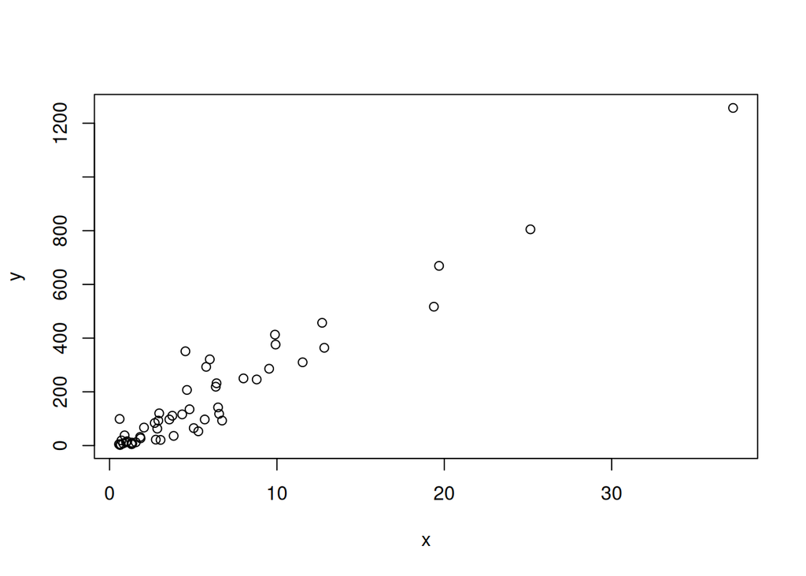

```r
x <- murders$population / 10^6
y <- murders$total
plot(x, y)
```

For a quick plot that avoids accessing variables twice, we can use the `with()` function:

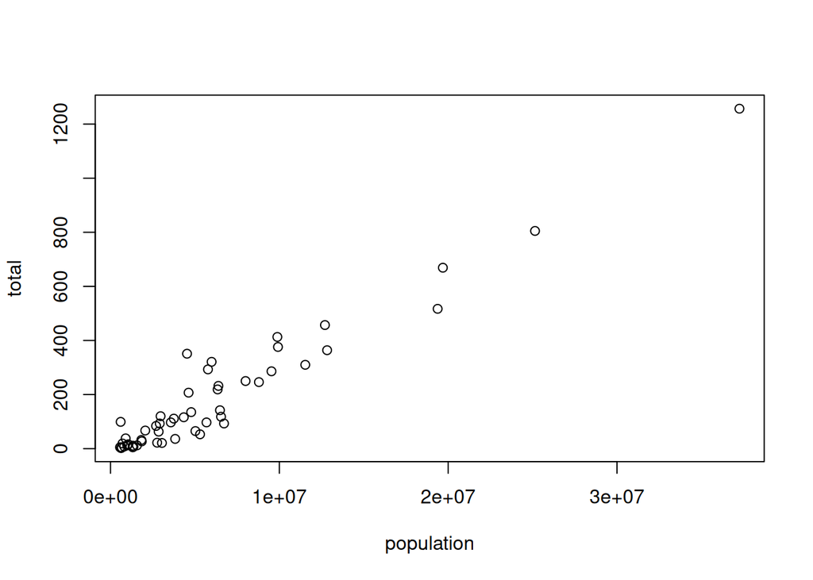

```r
with(murders, plot(population, total))
```

## 2.15.2 `hist()`

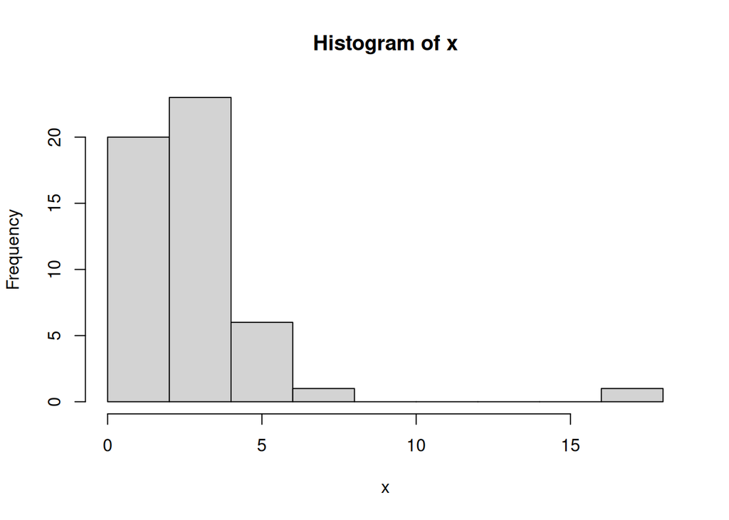

```r
x <- with(murders, total / population * 10^5)
hist(x)
```

We can see that there is a wide range of values with most of them between 2 and 3 and one very extreme case with a murder rate of more than 15:

```r
murders$state[which.max(x)]
```

```
## [1] "District of Columbia"
```

## 2.15.3 `boxplot()`

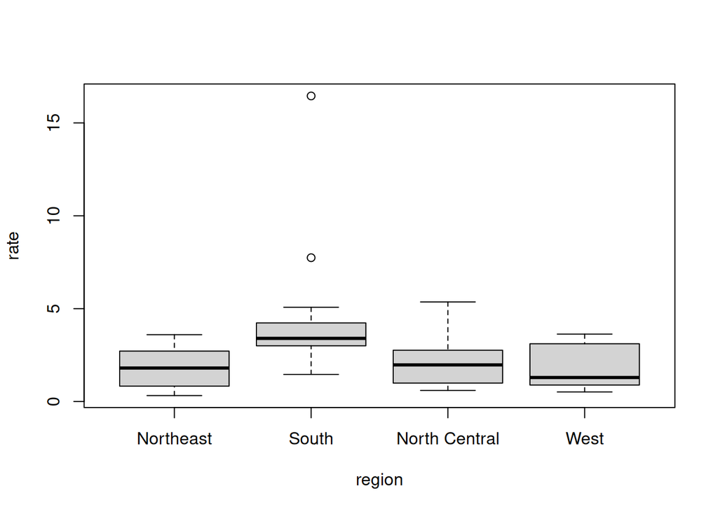

```r
murders$rate <- with(murders, total / population * 10^5)
boxplot(rate~region, data = murders)
```

## 2.15.4 `image()`

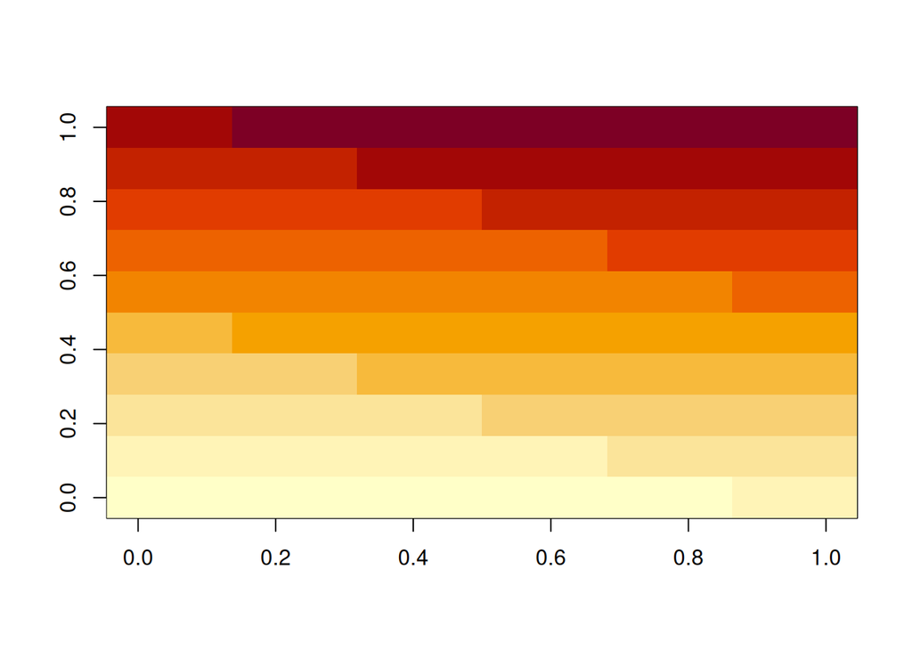

```r
x <- matrix(1:120, 12, 10)
image(x)
```

# 2.16 Exercises

1. We made a plot of total murders versus population and noted a strong relationship. Not surprisingly, states with larger populations had more murders.

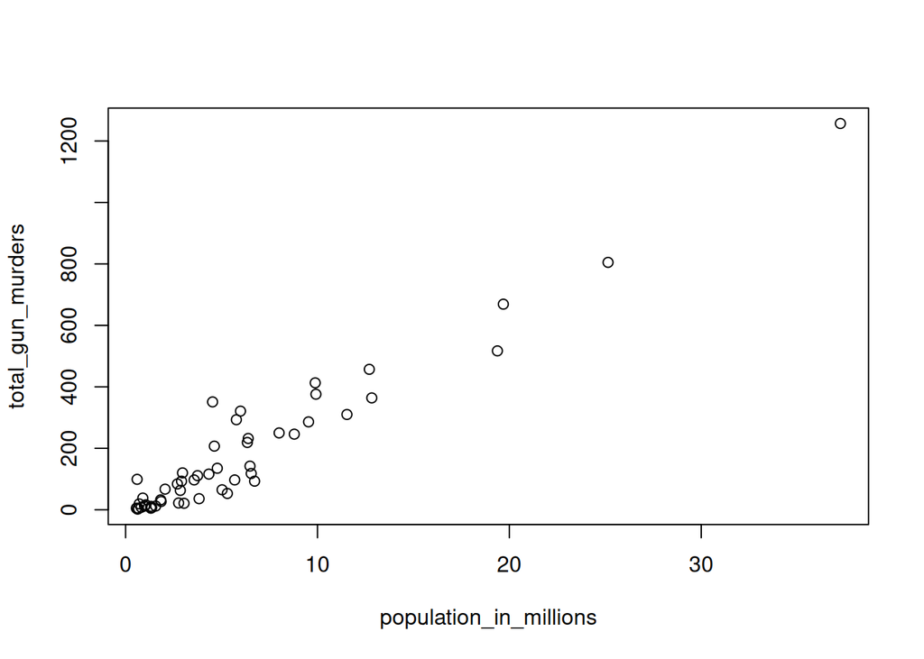

```r
# library(dslabs)
# data(murders)
population_in_millions <- murders$population/10^6
total_gun_murders <- murders$total
plot(population_in_millions, total_gun_murders)
```

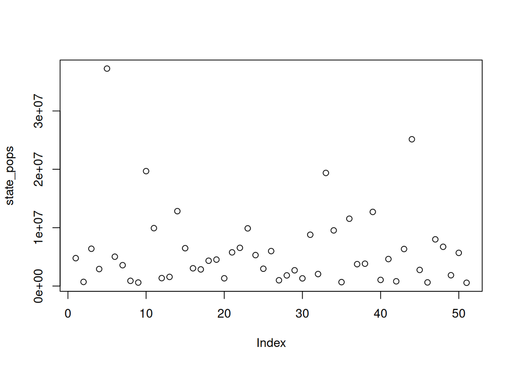

```r
state_pops = murders$population
plot(state_pops)
```

3. Generate boxplots of the state populations by region.

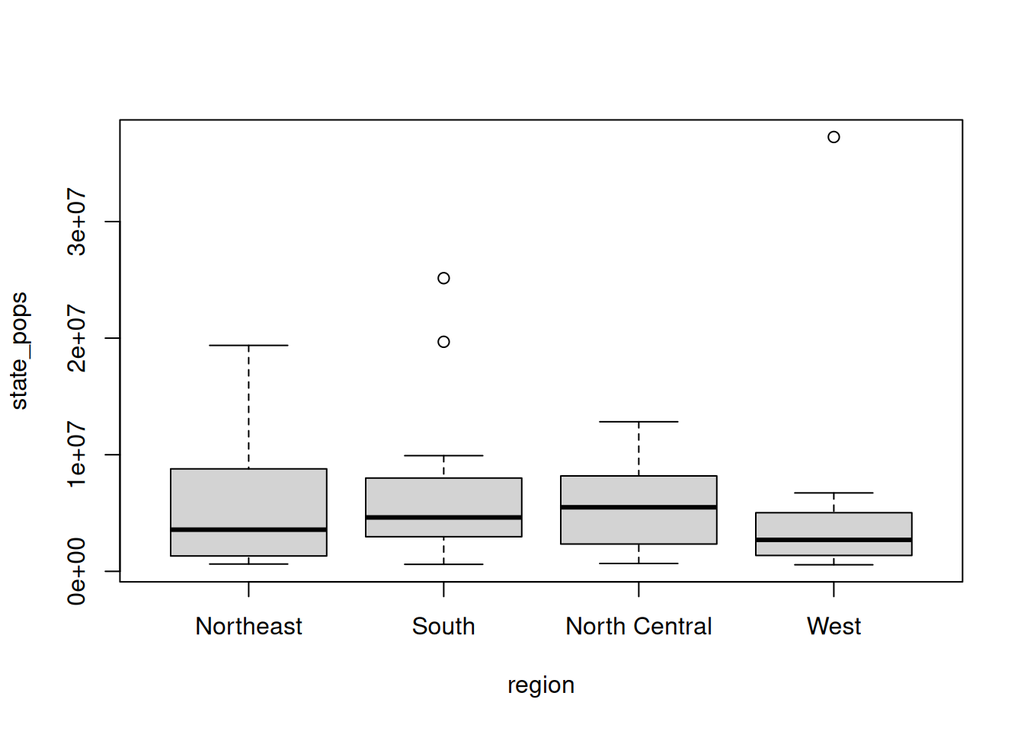

```r
boxplot(state_pops~region, data = murders)
```